# MAST30027_Assignment1

Zi Ng (1085130)

Thursday 4.55 - 5.15, Anubhav Kaphle

## Question 1

Fit a binomial regression model to the O-rings data from the Challenger disaster, using a complementary log-log link, from first principles

#### a) Compute the MLEs of model parameters.

First, we will load and inspect the data.

```r
# load data
library(faraway)
data(orings)
str(orings)
```

```
## 'data.frame':    23 obs. of  2 variables:
##  $ temp  : num  53 57 58 63 66 67 67 67 68 69 ...
##  $ damage: num  5 1 1 1 0 0 0 0 0 0 ...
```

We use the optim function to compute values for beta that maximize the log-likelihood.

```r
# log likelihood function
logL <- function(beta, orings) {
  eta <- cbind(1, orings$temp) %*% beta
  return (sum(orings$damage * log(exp(exp(eta)) - 1) - 6*exp(eta)))
}
# determine parameter estimates
(betahat <- optim(c(10, -0.1), logL, orings=orings, control=list(fnscale=-1))$par)
```

```
## [1] 10.8585961 -0.2054664
```

#### b) 95% CIs for the parameter estimates.

We now have the equations to compute the standard error of $\hat{\beta}$, which we can do in R.

```r
library(VGAM)
(phat <- clogloglink(betahat[1] + orings$temp * betahat[2], inverse=TRUE))
```

```
##  [1] 0.620672642 0.346974546 0.293188490 0.116804974 0.064859689 0.053139698
##  [7] 0.053139698 0.053139698 0.043488078 0.035556454 0.029049434 0.029049434
## [13] 0.029049434 0.029049434 0.019356199 0.015789673 0.010497099 0.010497099
## [19] 0.008555813 0.008555813 0.005680982 0.004628285 0.003071096
```

```r
mult <- (6 * (1-phat) * log(1-phat) / phat) * log(1-phat)
I11 <- sum(mult)
I12 <- sum(orings$temp * mult)
I22 <- sum(orings$temp^2 * mult)
Iinv <- solve(matrix(c(I11, I12, I12, I22), 2, 2))
(se.betahat1 <- sqrt(Iinv[1,1]))
```

```
## [1] 2.738166
```

```r
(se.betahat2 <- sqrt(Iinv[2,2]))
```

```
## [1] 0.04563258
```

Finally, we can compute the 95% confidence intervals for $\hat{\beta}$.

```r
# compute CI for betahat
betahat[1] + c(-1,1) * qnorm(0.975) * se.betahat1
```

```
## [1]  5.491889 16.225304
```

```r
betahat[2] + c(-1,1) * qnorm(0.975) * se.betahat2
```

```
## [1] -0.2949046 -0.1160282
```

#### c) Perform a likelihood ratio test for the significance of the temperature coefficient.

We are testing if $\hat{\beta_1}$ is significant in the model.
$$H_0: \beta_1 = 0 \\
H_1: \beta_1 \neq 0$$

First, we will compute the maximum log-likelihood for the full model, and the reduced model which does not include the temperature coefficient. We note that in the reduced model, $\hat{p}$ is the proportion of orings that were damaged in all the trials, given by $\frac{\sum y_i}{\sum m_i}$.

```r
# compute the maximum log-likelihood for the full model
(mll.full <- logL(betahat, orings))
```

```
## [1] -26.93787
```

```r
# compute the maximum log-likelihood for the reduced model
y <- orings$damage
n <- rep(6, length(y))
phatN <- sum(y) / sum(n)
(mll.red <- sum(y) * log(phatN) + sum(6-y) * log(1-phatN))
```

```
## [1] -38.3724
```

We then compute the Likelihood Ratio test statistic. Under the null hypothesis, we expect this test statistic to be chi-squared distributed with degrees of freedom $1$ since the full model has $2$ parameters, while the reduced model has $1$.

```r
(LR <- -2 * (mll.red - mll.full))
```

```
## [1] 22.86905
```

Hence, we can compute the p-value of the LR test statistic.

```r
pchisq(LR, df=1, lower=FALSE)
```

```
## [1] 1.734217e-06
```

Given a p-value of $<0.05$, we can thus conclude that the temperature coefficient is significant at a $95%$ confidence level.

#### d) Compute an estimate of the probability of damage when the temperature equals 31 Fahrenheit, as well as the 95% confidence interval for it.

We can estimate $\hat{\eta}$ from $\hat{\beta}$ since $\eta = \beta_0 + \beta_1 t$. We use that to obtain an estimate of $\hat{p}$ since we know $p = g^{-1}(\eta)$ where $g$ is the complementary log-log link function.

```r
# estimate of probability
etahat <- betahat[1] + betahat[2] * 31
(p.31f <- clogloglink(etahat, inverse=TRUE))
```

```
## [1] 1
```

To compute the confidence interval, we first need the standard error of $\hat{\eta}$.
$$se(\hat{p}) = \sqrt{
\left[\begin{array}{cc}
1 & 31\\
\end{array}\right]
I(\hat{\beta})^{-1}
\left[\begin{array}{cc}
1\\31
\end{array}\right]
}$$

```r
# se of p hat
si2 <- matrix(c(1, 31), 1, 2) %*% Iinv %*% matrix(c(1, 31), 2, 1)
```

Next, we compute the CI for $\hat{eta}$, which we can plug into the inverse link function to obtain a CI for $\hat{p}$.

```r
# CI for etahat
eta_l = etahat - qnorm(0.975) * sqrt(si2)
eta_r = etahat + qnorm(0.975) * sqrt(si2)
# 95% CI for p
c(clogloglink(eta_l, inverse=TRUE), clogloglink(eta_r, inverse=TRUE))
```

```
## [1] 0.9983804 1.0000000
```

#### e) Make a plot comparing the fitted complementary model to the fitted logit model.

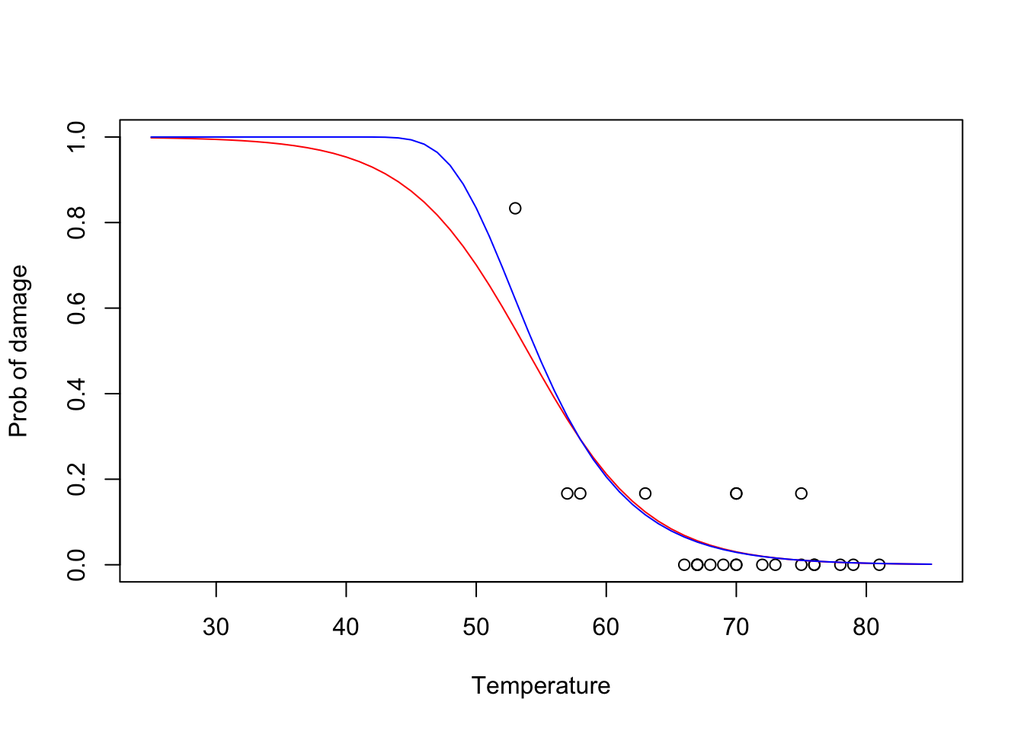

```r
# logit model
logitmodel <- glm(cbind(damage, 6-damage) ~ temp, family=stats::binomial, orings)

# plot fitted logit model
plot(damage/6 ~ temp, orings, xlim=c(25,85), ylim=c(0,1), xlab="Temperature", ylab="Prob of damage")
x <- seq(25,85,1)
ilogit <- function(x) exp(x) / (1+exp(x))
lines(x, ilogit(logitmodel$coefficients[1] + logitmodel$coefficients[2]*x), col="red")

# plot fitted cloglog model
icloglog <- function(x) 1 - exp(-exp(x))
lines(x, icloglog(betahat[1] + betahat[2] * x), col="blue")
```

## Question 2

Fit a binomial regression model with a logit link with test as a response and bmi as a predictor to the pima data set.

```r
# load the data
library(faraway)
missing <- with(pima, missing <- glucose==0 | diastolic==0 | triceps==0 | bmi==0)
pima_subset = pima[!missing, c(6,9)]
str(pima_subset)
```

```
## 'data.frame':    532 obs. of  2 variables:
##  $ bmi : num  33.6 26.6 28.1 43.1 31 30.5 30.1 25.8 45.8 43.3 ...
##  $ test: int  1 0 0 1 1 1 1 1 1 0 ...
```

```r
# fit a binomial regression model with logit link
pima_model <- glm(cbind(test, 1-test) ~ bmi, family=stats::binomial, pima)
summary(pima_model)
```

```
##
## Call:
## glm(formula = cbind(test, 1 - test) ~ bmi, family = stats::binomial,
##     data = pima)
##
## Deviance Residuals:
##     Min       1Q   Median       3Q      Max
## -1.9209  -0.9178  -0.6838   1.2351   2.7244
##
## Coefficients:
##             Estimate Std. Error z value Pr(>|z|)
## (Intercept) -3.68641    0.40896  -9.014  < 2e-16 ***
## bmi          0.09353    0.01205   7.761 8.45e-15 ***
## ---
## Signif. codes:  0 '***' 0.001 '**' 0.01 '*' 0.05 '.' 0.1 ' ' 1
##
## (Dispersion parameter for binomial family taken to be 1)
##
##     Null deviance: 993.48  on 767  degrees of freedom
## Residual deviance: 920.71  on 766  degrees of freedom
## AIC: 924.71
##
## Number of Fisher Scoring iterations: 4
```

#### a) Estimate in the amount of increase in the log(odds) when the bmi increases by 5.

$$\begin{align}
&\delta log(o)\\
&= log(o(t+5)) - log(o(t))\\
&= log(\frac{p(t+5)}{1-o(t+5)}) - log(\frac{p(t)}{1-p(t)})
&= \beta_0 +\beta_1(t+5) - \beta_0 - \beta_1 t
&= 5 \beta_1
\end{align}$$